# CWRU DSCI351-351m-451: Lab Exercise LE1

## LE1-3. (1 pt.) Data Basics: OpenIntroStats Exercise 1.9 1n Chapter 1, pg. 20.

Answer this in this Rmd file and

- explain what you are doing,
- i.e. show your R code and work.

#### OIS Exercise 1.9 Fisher’s irises, OISv4 page 20.

[Sir Ronald Aylmer Fisher](https://en.wikipedia.org/wiki/Ronald_Fisher) was

- An English statistician, evolutionary biologist, geneticist
  - and unfortunately a [eugenicist](https://en.wikipedia.org/wiki/Eugenics)
- Who worked on a data set that contained
  - sepal length and width, and petal length and width
  - from three species of iris flowers
    - (setosa, versicolor and virginica).
- There were 50 flowers from each species in the data set.

### (3a) How many cases were included in the data?

Show your R code!

```r
nrow(iris)
```

[output not shown]

ANSWER -> 150 cases

### (3b) How many numerical variables are included in the data?

- Indicate what they are, and
- if they are continuous or discrete.

```r
str(iris)
numeric_cols <- unlist(lapply(iris, is.numeric))
numeric_cols
ncol(iris[ , numeric_cols])
discrete_cols <- unlist(lapply(iris, is.integer))
continuous_cols <- unlist(lapply(iris, is.double))
discrete_cols
continuous_cols
```

[output not shown]

ANSWER -> There are 4 numerical variables: Petal.Length, Petal.Width, Sepal.Length, Sepal.Width. None of them are discrete(integer/whole numbers), all of them are continuous(double/decimal numbers)

### (3c) How many categorical variables are included in the data,

- and what are they?
- List the corresponding levels (categories).

```r
str(iris)
```

```
'data.frame':   150 obs. of  5 variables:
 $ Sepal.Length: num  5.1 4.9 4.7 4.6 5 5.4 4.6 5 4.4 4.9 ...
 $ Sepal.Width : num  3.5 3 3.2 3.1 3.6 3.9 3.4 3.4 2.9 3.1 ...
 $ Petal.Length: num  1.4 1.4 1.3 1.5 1.4 1.7 1.4 1.5 1.4 1.5 ...
 $ Petal.Width : num  0.2 0.2 0.2 0.2 0.2 0.4 0.3 0.2 0.2 0.1 ...
 $ Species     : Factor w/ 3 levels "setosa","versicolor",..: 1 1 1 1 1 1 1 1 1 1 ...
```

```r
categorical_cols <- unlist(lapply(iris, is.factor))
categorical_cols
```

```
Sepal.Length  Sepal.Width Petal.Length  Petal.Width      Species
       FALSE        FALSE        FALSE        FALSE         TRUE
```

```r
levels(iris[ , categorical_cols])
```

```
[1] "setosa"     "versicolor" "virginica"
```

ANSWER -> 1 categorical variable: Species. 3 levels: setosa, versicolor, virginica

## LE1-4. (1 pt.) Examining Numerical Data:. Distributions and Appropriate Statistics

OISv4 Exercise 2.16 p. 59.

For each of the following, answer three things

1. State whether you expect the distribution to be
- symmetric,
- right skewed,
- or left skewed.
2. Also specify whether the mean or median
- would best represent a typical observation in the data,
3. and whether the variability of observations
- would be best represented
- using the standard deviation or IQR.

Explain your reasoning.

### (LE1-4a) Housing prices in a country

- where 25% of the houses cost below $350,000,
- 50% of the houses cost below $450,000,
- 75% of the houses cost below $1,000,000
- and there are a meaningful number of houses that cost more than $6,000,000.

ANSWER -> Quartiles: Q1 = 350000, Q2 = 450000, Q3 = 1000000 Diff1 = Q2-Q1 = 100000; Diff2 = Q3-Q2 = 550000 Diff2 > Diff1 => The distribution would be right skewed If the distribution is right skewed, then 1 - Median would best represent a typical observation in data 2 - IQR would best represent the variability of observations

### (LE1-4b) Housing prices in a country where

- 25% of the houses cost below $300,000,
- 50% of the houses cost below $600,000,
- 75% of the houses cost below $900,000
- and very few houses that cost more than $1,200,000.

ANSWER -> Quartiles: Q1 = 300000, Q2 = 600000, Q3 = 900000 Diff1 = Q2-Q1 = 300000; Diff2 = Q3-Q2 = 300000 Diff2 = Diff1 => The distribution would be symmetric If the distribution is symmetric, then 1 - Mean would best represent a typical observation in data 2 - Standard Deviation would best represent the variability of observations

### (LE1-4c) Number of alcoholic drinks consumed by college students in a given week.

Assume that most of these students don’t drink

- since they are under 21 years old,
- and only a few drink excessively.

ANSWER -> On average, there are 4 years of college and most students hit 21 on their second half of third year or first half of fourth year. Given the assumption that most students don’t drink due to age restrictions and that a few drink excessively, the distribution is expected to be right skewed. If the distribution is right skewed, then 1 - Median would best represent a typical observation in data 2 - IQR would best represent the variability of observations

### (LE1-4d) Annual salaries of the employees at a Fortune 500 company

- where only a few high level executives earn much higher salaries
- than all the other employees.

ANSWER -> In this case it would be right skewed, a few high level executives earn “much higher” salaries than the others. If the distribution is right skewed, then 1 - Median would best represent a typical observation in data 2 - IQR would best represent the variability of observations

## LE1-5. (1 pt.) Examining Numerical Data: OpenIntroStats Exercise 2.9

in OISv4 Chapter 2, pg 57.

#### Exercise 2.9 Means and SDs.

For each part, compare distributions (1) and (2)

- based on their means and standard deviations.

You do not need to calculate these statistics;

- simply state how the means and the standard deviations compare.

Make sure to explain your reasoning.

- Hint: It may be useful to sketch dot plots of the distributions.

### LE1-5a)

```
(1) 3, 5, 6, 7, 9
(2) 3, 5, 6, 7, 20
```

```r
aLisOne <- c(3, 5, 6, 7, 9)
aLisTwo <- c(3, 5, 6, 7, 20)

mean(aLisOne)
```

```
[1] 6
```

```r
sd(aLisOne)
```

```
[1] 2.236068
```

```r
mean(aLisTwo)
```

```
[1] 8.2
```

```r
sd(aLisTwo)
```

```
[1] 6.760178
```

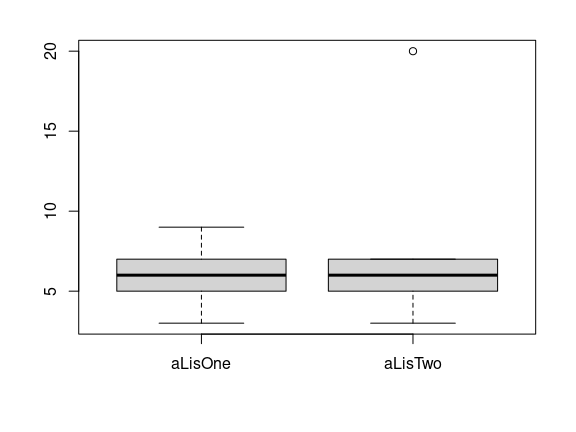

```r
adf <- data.frame(aLisOne, aLisTwo)
boxplot(adf)
```

ANSWER -> Mean differs on the value of the last element of each distribution. Because the value of the last element of the second distribution is more than double the value of the last element of the first distribution, the standard deviation (as well as the mean) has a greater value, and gives a greater spread of the acceptable data. This difference makes the mean and the standard deviation more difficult to interpret, and makes them false indicators of what the data should actually represent. The data is skewed towards the greatest value.

### LE1-5b)

```
(1) 3, 5, 6, 7, 9
(2) 3, 5, 7, 8, 9
```

```r
bLisOne <- c(3, 5, 6, 7, 9)
bLisTwo <- c(3, 5, 7, 8, 9)

mean(bLisOne)
```

```
[1] 6
```

```r
sd(bLisOne)
```

```
[1] 2.236068
```

```r
mean(bLisTwo)
```

```
[1] 6.4
```

```r
sd(bLisTwo)
```

```
[1] 2.408319
```

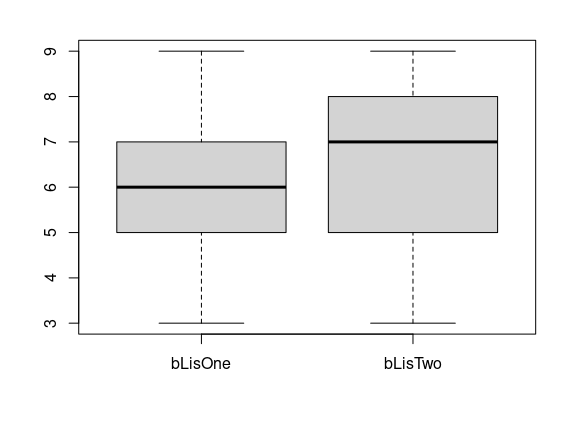

```r
bdf <- data.frame(bLisOne, bLisTwo)
boxplot(bdf)
```

ANSWER -> Range of acceptable values remains the same, mean and sd of the second distribution is slightly greater than the mean of the first. otherwise, both share a similar determination of the distribution.

### LE1-5c)

```
(1) 1, 2, 3, 4, 5
(2) 6, 7, 8, 9, 10
```

```r
cLisOne <- c(1, 2, 3, 4, 5)
cLisTwo <- c(6, 7, 8, 9, 10)

mean(cLisOne)
```

```
[1] 3
```

```r
sd(cLisOne)
```

```
[1] 1.581139
```

```r
mean(cLisTwo)
```

```
[1] 8
```

```r
sd(cLisTwo)
```

```
[1] 1.581139
```

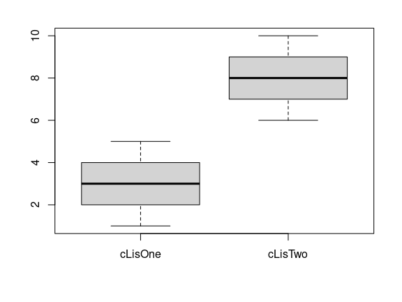

```r
cdf <- data.frame(cLisOne, cLisTwo)
boxplot(cdf)
```

ANSWER -> Standard deviation is the same on both distributions because the spread of the numbers in the distributions are the same. Mean is only different because the number ranges are different. Scale is maintained.

### LE1-5d)

```
(1) 0, 10, 50, 60, 100
(2) 0, 100, 500, 600, 1000
```

```r
dLisOne <- c(0, 10, 50, 60, 100)
dLisTwo <- c(0, 100, 500, 600, 1000)

mean(dLisOne)
```

```
[1] 44
```

```r
sd(dLisOne)
```

```
[1] 40.37326
```

```r
mean(dLisTwo)
```

```
[1] 440
```

```r
sd(dLisTwo)
```

```
[1] 403.7326
```

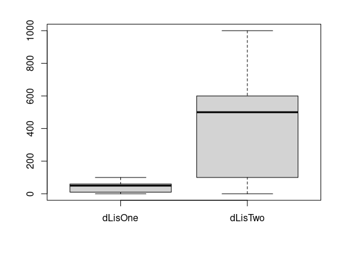

```r
ddf <- data.frame(dLisOne, dLisTwo)
boxplot(ddf)
```

ANSWER -> The second distribution is a multiple of the first, so it implies that the mean and standard distribution scale accordingly with the multiple.